# Assignment4

crator-creator/20162306임유석

2021 5 3

## **1. Predicting Delayed Flights**

항공기의 연착(delay) 여부를 예측하는 것은 항공사와 공항 등 항공기 운항과 관련된 주체들에게 매우 중요하다. 항공기의 연착에 따라 대체 항공기 이용료, 숙박 비용, 공항 사용료 등의 비용 발생이 매우 크기 때문이다. FlightRecords.csv 파일은 2004년 1월동안 Washington, DC 지역으로부터 New York City로 운행한 2201개 의 항공기 운행 기록을 포함한다. 본 문제에서는 다음 7개의 변수를 사용하여 항공기의 연착 여부를 예측해 본다.

- dayweek: 운행 요일 (1: Mon, 2: Tue, …, 7: Sun)
- deptime: 출발시각 (예: 1455 = 14시55분, 839: 8시39분)
- origin: 출발공항코드(DCA: Reagan Nation, IAD: Dulles, BWI: Baltimore-Washington Int’l)
- dest: 도착공항코드(JFK: Kennedy, LGA: LaGuardia, EWR: Newark)
- carrier: 항공사코드(CO: Continental, DH: Atlantic Coast, DL: Delta, MQ: American Eagle  
  OH: Comair, RU: Continental Express, UA: United, US: USAirways)
- weather: 날씨 (0: OK, 1: Bad)
- delay: 연착여부(“delayed” or “ontime”)

```r
# 사용할 패키지 추가
library(ggplot2)
library(psych)
library(caret)
library(e1071)
library(rsample)
library(ISLR)
library(glmnet)
library(ROCR)
```

### 1-1. 다음의 순서로 data preprocessing을 진행하자.

- 항공기 출발시각(deptime)이 6시 이전이거나 22시 이후인 데이터는 빈도 수가 매우 적으므로 데이 터셋에서 제외시킨다.
- 수치값으로 표현되어 있는 출발시각을 6시부터 22시까지 각 시간대를 나타내는 범주형 변수로 변환 한다 (Hint: 원 데이터를 100으로 나눈 후 정수값으로 내림. 그 후 factor로 변환)
- 수치값으로 표현되어 있는 dayweek와 weather 변수를 factor로 변환한다.
- factor로 표현되어 있는 delay 변수가 가지는 level의 순서를 “ontime”, “delayed” 순으로 변환한 다 (logistic regression 수행 시에 연착하는 경우를 로 만들기 위해서).

```r
#데이터 읽기
records = read.csv("./data/FlightRecords.csv")
#6시 이전, 22시 이후 데이터 제외
records=records[records$deptime>600 & records$deptime < 2300, ]
#출발시각 전처리
records$deptime=as.factor(floor(records$deptime/100))
#factor
records$dayweek = as.factor(records$dayweek)
records$weather = as.factor(records$weather)
#target feature 전처리
records$delay = factor(records$delay, level=c("ontime","delayed"), labels=c("ontime","delayed"))
#필요없는 feature 제외
records=records[-c(1,5,6,7,11,12)]
```

### 1-2. 요일 별 연착비율, 출발 시간대 별 연착 비율, 출발 공항 별 연착비율, 도착 공항 별 연착 비율, 항공사 별 연착비율, 날씨 별 연착 비율을 각각 그래프로 시각화해보자. 어떤 특성을 관찰할 수 있는가?

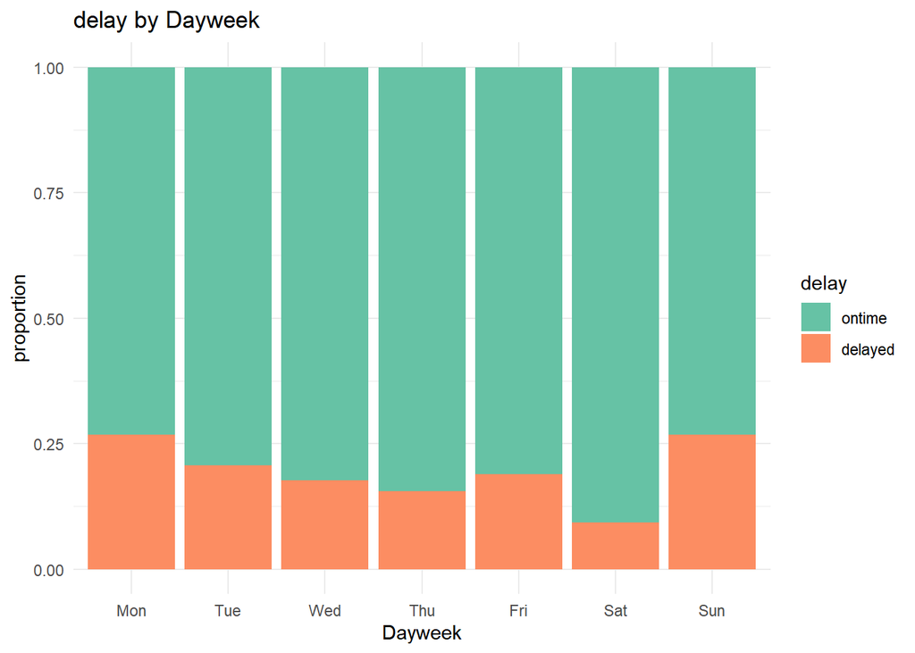

```r
#요일별 연착비율
ggplot(records, aes(x=factor(dayweek,levels=c(1,2,3,4,5,6,7),labels=c("Mon","Tue","Wed","Thu","Fri","Sat","Sun")), fill=delay))+ geom_bar(position="fill")+labs(x="Dayweek",y="proportion",title="delay by Dayweek")+scale_fill_brewer(palette="Set2")+theme_minimal()
```

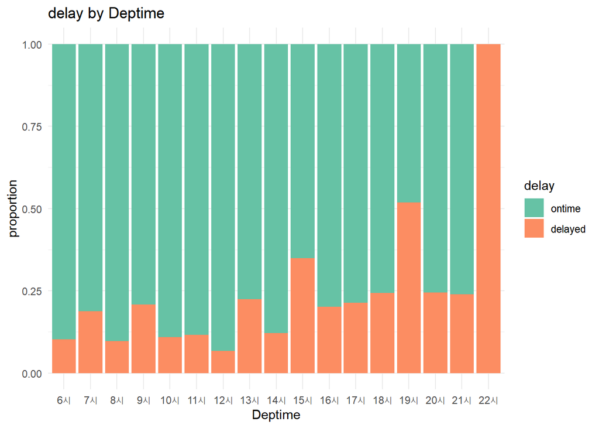

```r
#출발 시간대 별 연착 비율
ggplot(records, aes(x=factor(deptime,levels=c(6,7,8,9,10,11,12,13,14,15,16,17,18,19,20,21,22),labels=c("6시","7시","8시","9시","10시","11시","12시","13시","14시","15시","16시","17시","18시","19시","20시","21시","22시")), fill=delay))+ geom_bar(position="fill")+labs(x="Deptime",y="proportion",title="delay by Deptime")+scale_fill_brewer(palette="Set2")+theme_minimal()
```

- 대체로 시간이 지날 수록 delayed의 비율이 증가하며 특히 22시에는 모든 비행기가 delayed되었다.

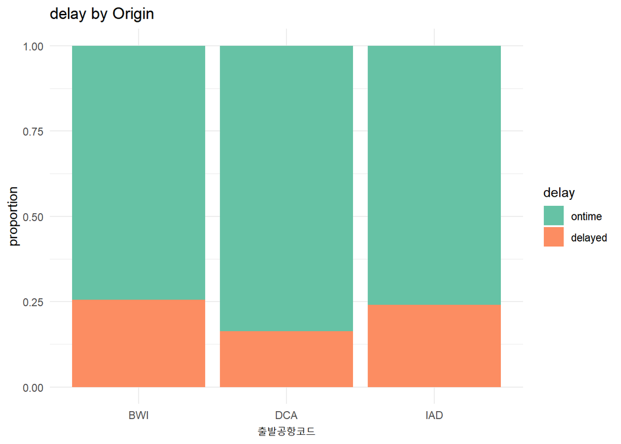

```r
#출발 공항 별 연착비율
ggplot(records, aes(x=origin, fill=delay))+ geom_bar(position="fill")+labs(x="출발공항코드",y="proportion",title="delay by Origin")+scale_fill_brewer(palette="Set2")+theme_minimal()
```

- 대체로 ontime의 비율이 delayed 비율보다 높게 나타나며 출발공항별 delay 비율은 DCA공항이 약간 작으나 비슷하게 나타난다.

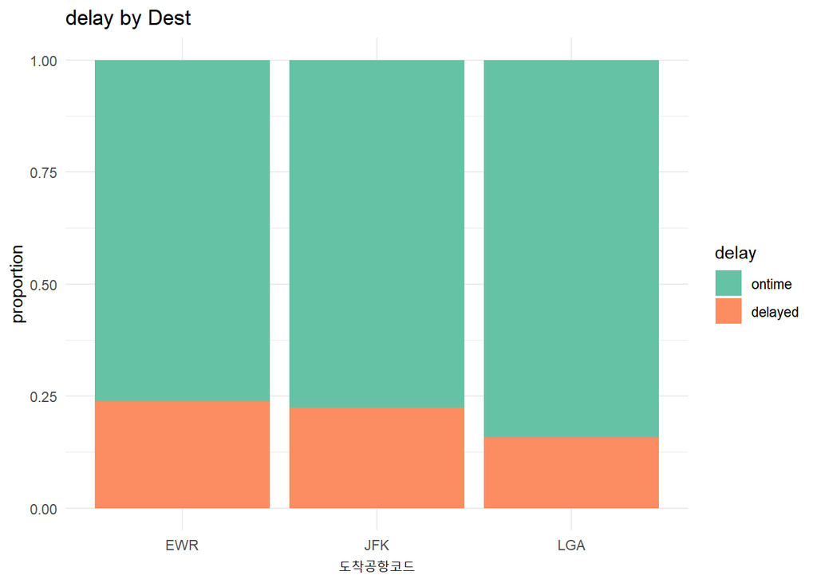

```r
#도착 공항 별 연착비율
ggplot(records, aes(x=dest, fill=delay))+ geom_bar(position="fill")+labs(x="도착공항코드",y="proportion",title="delay by Dest")+scale_fill_brewer(palette="Set2")+theme_minimal()
```

- 대체로 ontime의 비율이 delayed 비율보다 높게 나타나며 도착공항별 delay 비율은 LGA공항이 약간 작으나 비슷하게 나타난다.

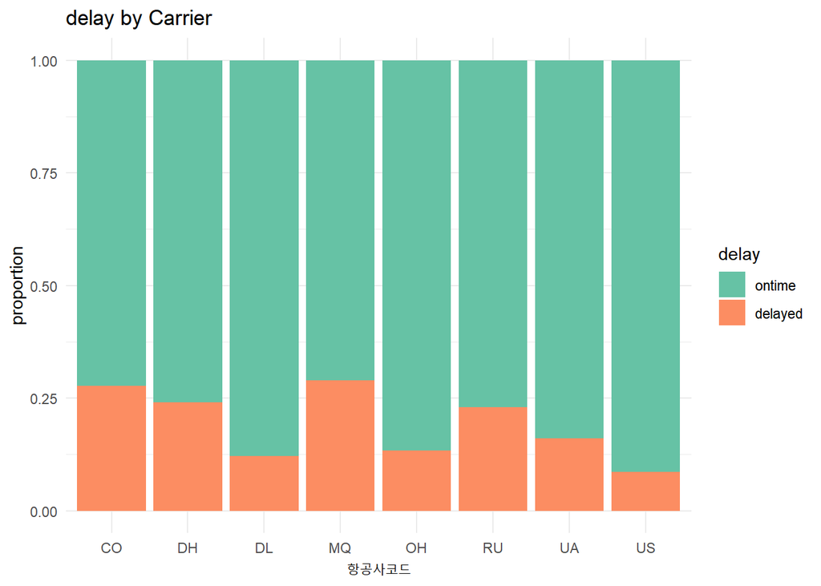

```r
#항공사 별 연착비율
ggplot(records, aes(x=carrier, fill=delay))+ geom_bar(position="fill")+labs(x="항공사코드",y="proportion",title="delay by Carrier")+scale_fill_brewer(palette="Set2")+theme_minimal()
```

- 대체로 ontime의 비율이 delayed 비율보다 높게 나타나며 DL,OH,US항공사가 delayed비율이 비교적 적다.

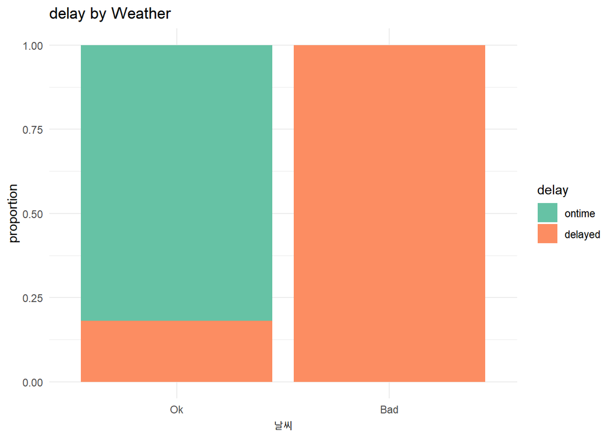

```r
#날씨 별 연착비율
ggplot(records, aes(x=factor(weather,level=c(0,1),labels = c("Ok","Bad")), fill=delay))+ geom_bar(position="fill")+labs(x="날씨",y="proportion",title="delay by Weather")+scale_fill_brewer(palette="Set2")+theme_minimal()
```

- 날씨가 좋지 않을 경우 100% delayed된다.

### 1-3. 7개의 모든 변수들 간의 상관관계를 시각화해보자. 어떤 특성을 관찰할 수 있는가?

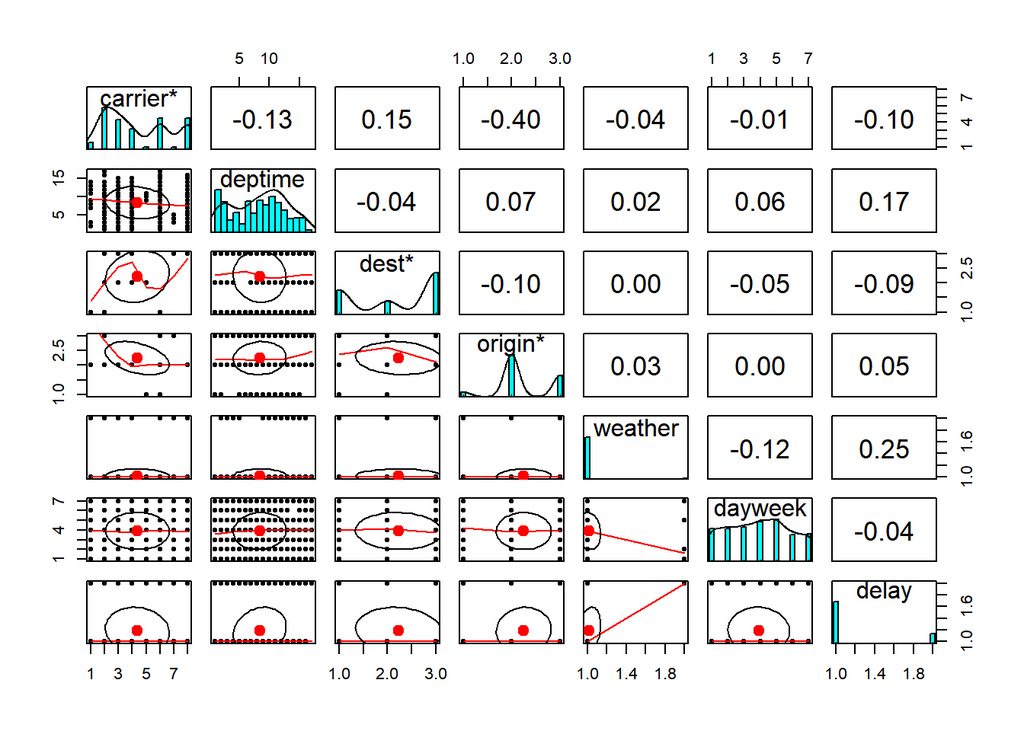

```r
#모든 변수 상관관계 시각화
pairs.panels(records)
```

- 모든 변수와 타겟 변수와의 상관관계가 비교적 낮음. 하지만 날씨 데이터와 타겟변수의 상관관계는 6개의 feature 변수 중 가장 높음.
- 각 feature들 변수 사이의 상관관계도 비교적 낮으나 carrier 와 origin은 그 중 음의 상관관계를 보임.

### 1-4. 데이터셋을 70:30 비율로 training set과 test set으로 분할하자. 이때 stratified sampling을 활용하여 두 set에서 delay 변수의 분포가 크게 차이가 없도록 분할하자

```r
#데이터 분할
set.seed(123)
split = initial_split(records, prop=0.7, strat="delay")
train = training(split)
test = testing(split)
```

### 1-5. 데이터시각화로부터 weather 변수가 “Bad” 인 경우에는 항상 항공기가 연착되는 것을 관찰할 수 있다. 따라서 weather가 Bad이면 항공기가 연착되고, weather가 OK일 경우 항공기가 연착되지 않는 것으로 예측하는 단순한모델을 baseline model이라 하자. Test set에 대해 baseline model을 적용했을 때 confusion matrix를 계산해 보세요

```r
#baseline model
pred_base = factor(test$weather, levels=c(0,1), labels=c("ontime","delayed"))
confusionMatrix(pred_base, test$delay, positive="ontime")
```

```
## Confusion Matrix and Statistics
##
##           Reference
## Prediction ontime delayed
##    ontime     525     116
##    delayed      0      10
##
##                Accuracy : 0.8218
##                  95% CI : (0.7902, 0.8505)
##     No Information Rate : 0.8065
##     P-Value [Acc > NIR] : 0.1733
##
##                   Kappa : 0.1221
##
##  Mcnemar's Test P-Value : <2e-16
##
##             Sensitivity : 1.00000
##             Specificity : 0.07937
##          Pos Pred Value : 0.81903
##          Neg Pred Value : 1.00000
##              Prevalence : 0.80645
##          Detection Rate : 0.80645
##    Detection Prevalence : 0.98464
##       Balanced Accuracy : 0.53968
##
##        'Positive' Class : ontime
##
```

- weather feature을 가지고 예측하였을 때 116개의 데이터를 분류하지 못하였다.
- 정확도는 약 82%를 보인다.
- sensitivity는 1.0이며 specificity는 0.07937이며 이는 matrix에서 부정을 걸러내지 못한것을 통해 알 수 있다.

### 1-6. Training set을 대상으로, 연착여부(delay)를 나머지 모든 변수를 사용하여 예측하기 위한 logistic regression model을 수립해보자.

```r
#모델 생성
model = glm(delay~., data=train, family="binomial")
summary(model)
```

```
##
## Call:
## glm(formula = delay ~ ., family = "binomial", data = train)
##
## Deviance Residuals:
##     Min       1Q   Median       3Q      Max
## -1.6196  -0.6401  -0.4492  -0.2447   2.8928
##
## Coefficients:
##              Estimate Std. Error z value Pr(>|z|)
## (Intercept)  -0.04278    0.61589  -0.069 0.944624
## carrierDH    -0.43306    0.55843  -0.775 0.438045
## carrierDL    -0.88644    0.51912  -1.708 0.087717 .
## carrierMQ     0.05333    0.50149   0.106 0.915304
## carrierOH    -1.70543    0.90674  -1.881 0.059993 .
## carrierRU    -0.72738    0.43590  -1.669 0.095180 .
## carrierUA    -0.57680    0.96015  -0.601 0.548015
## carrierUS    -1.32113    0.53279  -2.480 0.013151 *
## deptime7      0.41724    0.50450   0.827 0.408217
## deptime8     -0.16443    0.48338  -0.340 0.733731
## deptime9      1.61586    0.50692   3.188 0.001435 **
## deptime10    -0.29976    0.52148  -0.575 0.565415
## deptime11     0.81661    0.60620   1.347 0.177950
## deptime12    -0.44975    0.48257  -0.932 0.351342
## deptime13     1.01013    0.43682   2.312 0.020753 *
## deptime14     0.01354    0.43261   0.031 0.975032
## deptime15     1.82352    0.39358   4.633 3.60e-06 ***
## deptime16     1.07849    0.40094   2.690 0.007148 **
## deptime17     0.94033    0.39071   2.407 0.016097 *
## deptime18     1.18072    0.43033   2.744 0.006074 **
## deptime19     2.64120    0.44656   5.914 3.33e-09 ***
## deptime20     1.70637    0.46197   3.694 0.000221 ***
## deptime21     0.65887    0.46346   1.422 0.155135
## deptime22    18.95975  827.05199   0.023 0.981710
## destJFK      -0.49508    0.33242  -1.489 0.136399
## destLGA      -0.12074    0.33780  -0.357 0.720760
## originDCA    -1.53338    0.37971  -4.038 5.38e-05 ***
## originIAD    -0.81190    0.37569  -2.161 0.030686 *
## weather1     17.70437  487.18601   0.036 0.971011
## dayweek2     -0.45117    0.27287  -1.653 0.098242 .
## dayweek3     -0.50327    0.26044  -1.932 0.053314 .
## dayweek4     -0.55876    0.25913  -2.156 0.031060 *
## dayweek5     -0.26692    0.24534  -1.088 0.276616
## dayweek6     -1.42097    0.36037  -3.943 8.04e-05 ***
## dayweek7     -0.01325    0.26927  -0.049 0.960764
## ---
## Signif. codes:  0 '***' 0.001 '**' 0.01 '*' 0.05 '.' 0.1 ' ' 1
##
## (Dispersion parameter for binomial family taken to be 1)
##
##     Null deviance: 1492.7  on 1518  degrees of freedom
## Residual deviance: 1200.3  on 1484  degrees of freedom
## AIC: 1270.3
##
## Number of Fisher Scoring iterations: 15
```

#### 1-6-1. 변수 deptime19의 regression coefficient에 대한 추정값은 얼마인가? 이 추정값을 바탕으로 출발시각이 19시대인 항공기에 대해서 어떠한 해석을 할 수 있는가?

- deptime19의 베타 추정값은 2.64120이다.
- 추정값이 양수이므로 deptime19가 증가할 수록 delay확률이 증가하며 그 정도는 2.64120이다.

#### 1-6-2. 날씨에 문제가 없는 금요일 15시에 IAD에서 출발하여 JFK로 도착한 Delta 항공기가 연착될 확률은 얼마로 예측되는가?

```r
#데이터 생성
#test데이터를 하나 가져와서 조건에 맞게 값 수정
test_A = test[1,]
test_A[1,]=c("DL", 15, "JFK","IAD",0,5,"delayed")
#예측
predict(model, test_A, type="response")
```

```
##         6
## 0.3363504
```

- 위 조건을 만족한 data의 확률은 약 33%로 예측된다.

#### 1-6-3. Threshold 에 대해서 각각 test set에 대한 confusion matrix를 계산해 보자. 어떠한 경향을 관찰할 수 있는가?

```r
#t=0.2
test_prob = predict(model, test, type="response")
test_pred = rep("ontime",651)
test_pred[test_prob > 0.2] = "delayed"
confusionMatrix(factor(test_pred, levels=c("ontime","delayed")), test$delay, positive="delayed")
```

```
## Confusion Matrix and Statistics
##
##           Reference
## Prediction ontime delayed
##    ontime     370      49
##    delayed    155      77
##
##                Accuracy : 0.6866
##                  95% CI : (0.6494, 0.7221)
##     No Information Rate : 0.8065
##     P-Value [Acc > NIR] : 1
##
##                   Kappa : 0.2394
##
##  Mcnemar's Test P-Value : 1.96e-13
##
##             Sensitivity : 0.6111
##             Specificity : 0.7048
##          Pos Pred Value : 0.3319
##          Neg Pred Value : 0.8831
##              Prevalence : 0.1935
##          Detection Rate : 0.1183
##    Detection Prevalence : 0.3564
##       Balanced Accuracy : 0.6579
##
##        'Positive' Class : delayed
##
```

```r
#t=0.3
test_pred = rep("ontime",651)
test_pred[test_prob > 0.3] = "delayed"
confusionMatrix(factor(test_pred, levels=c("ontime","delayed")), test$delay, positive="delayed")
```

```
## Confusion Matrix and Statistics
##
##           Reference
## Prediction ontime delayed
##    ontime     460      71
##    delayed     65      55
##
##                Accuracy : 0.7911
##                  95% CI : (0.7578, 0.8217)
##     No Information Rate : 0.8065
##     P-Value [Acc > NIR] : 0.8511
##
##                   Kappa : 0.3185
##
##  Mcnemar's Test P-Value : 0.6681
##
##             Sensitivity : 0.43651
##             Specificity : 0.87619
##          Pos Pred Value : 0.45833
##          Neg Pred Value : 0.86629
##              Prevalence : 0.19355
##          Detection Rate : 0.08449
##    Detection Prevalence : 0.18433
##       Balanced Accuracy : 0.65635
##
##        'Positive' Class : delayed
##
```

```r
#t=0.5
test_pred = rep("ontime",651)
test_pred[test_prob > 0.5] = "delayed"
confusionMatrix(factor(test_pred, levels=c("ontime","delayed")), test$delay, positive="delayed")
```

```
## Confusion Matrix and Statistics
##
##           Reference
## Prediction ontime delayed
##    ontime     517      98
##    delayed      8      28
##
##                Accuracy : 0.8372
##                  95% CI : (0.8065, 0.8647)
##     No Information Rate : 0.8065
##     P-Value [Acc > NIR] : 0.02472
##
##                   Kappa : 0.2841
##
##  Mcnemar's Test P-Value : < 2e-16
##
##             Sensitivity : 0.22222
##             Specificity : 0.98476
##          Pos Pred Value : 0.77778
##          Neg Pred Value : 0.84065
##              Prevalence : 0.19355
##          Detection Rate : 0.04301
##    Detection Prevalence : 0.05530
##       Balanced Accuracy : 0.60349
##
##        'Positive' Class : delayed
##
```

```r
#t=0.7
test_pred = rep("ontime",651)
test_pred[test_prob > 0.7] = "delayed"
confusionMatrix(factor(test_pred, levels=c("ontime","delayed")), test$delay, positive="delayed")
```

```
## Confusion Matrix and Statistics
##
##           Reference
## Prediction ontime delayed
##    ontime     524     107
##    delayed      1      19
##
##                Accuracy : 0.8341
##                  95% CI : (0.8033, 0.8619)
##     No Information Rate : 0.8065
##     P-Value [Acc > NIR] : 0.03936
##
##                   Kappa : 0.2189
##
##  Mcnemar's Test P-Value : < 2e-16
##
##             Sensitivity : 0.15079
##             Specificity : 0.99810
##          Pos Pred Value : 0.95000
##          Neg Pred Value : 0.83043
##              Prevalence : 0.19355
##          Detection Rate : 0.02919
##    Detection Prevalence : 0.03072
##       Balanced Accuracy : 0.57444
##
##        'Positive' Class : delayed
##
```

- t 의 값이 0.5인경우 가장 높은 정확도를 보이고(0.7인경우도 유사함.) 대체로 0.2에서 높아질 수록 정확도가 증가한다.
- t 값의 증가할 때 sensitivity 와 specificity는 trade-off 관계에 있음을 알 수 있다.

#### 1-6-4. Baseline model과 logistic regression model의 성능을 비교해보자.

- Baseline model 의 정확도는 약 82%, logistic regression model의 정확도는(t=0.5) 약 83%로 logistic model이 1%더 높다.
- logistic 모델이 근소하게 정확도가 높으나 feature의 갯수가 baseline model에 비해 6개 많이 사용되었으므로 더 간단하면서 성능이 높은것은 baseline model이라고도 할 수 있다.

### 1-7.Training set을 대상으로, step() 함수를 활용한 backward stepwise selection을 적용하여 logistic regression model을 수립해보자

```r
#backward selection
set.seed(123)
model_step = step(model, direction="backward")
```

```
## Start:  AIC=1270.27
## delay ~ carrier + deptime + dest + origin + weather + dayweek
##
##           Df Deviance    AIC
## - dest     2   1203.4 1269.4
## <none>         1200.3 1270.3
## - dayweek  6   1224.0 1282.0
## - origin   2   1217.2 1283.2
## - carrier  7   1228.6 1284.6
## - weather  1   1254.6 1322.6
## - deptime 16   1343.5 1381.5
##
## Step:  AIC=1269.41
## delay ~ carrier + deptime + origin + weather + dayweek
##
##           Df Deviance    AIC
## <none>         1203.4 1269.4
## - origin   2   1220.6 1282.6
## - dayweek  6   1229.2 1283.2
## - carrier  7   1234.0 1286.0
## - weather  1   1257.6 1321.6
## - deptime 16   1343.5 1377.5
```

```r
#상관계수
coef(model_step)
```

```
## (Intercept)   carrierDH   carrierDL   carrierMQ   carrierOH   carrierRU
##  0.02282777 -0.71799697 -1.01974371 -0.15430796 -2.15129990 -0.73030171
##   carrierUA   carrierUS    deptime7    deptime8    deptime9   deptime10
## -0.75761094 -1.43505156  0.38316496 -0.20655071  1.53466983 -0.31785796
##   deptime11   deptime12   deptime13   deptime14   deptime15   deptime16
##  0.77410640 -0.48095589  0.99627517 -0.05302110  1.70423966  0.93411989
##   deptime17   deptime18   deptime19   deptime20   deptime21   deptime22
##  0.88649962  1.06105707  2.58541713  1.63926733  0.62083984 18.87277139
##   originDCA   originIAD    weather1    dayweek2    dayweek3    dayweek4
## -1.52819929 -0.75172288 17.69961026 -0.46894663 -0.51162398 -0.57750267
##    dayweek5    dayweek6    dayweek7
## -0.27131599 -1.46724531 -0.01940330
```

```r
#확률
prob_step = predict(model_step, test, type="response")
#threshold값 을 통한 test데이터 예측
pred_step = rep("ontime",651)
pred_step[prob_step>0.5] = "delayed"
confusionMatrix(factor(pred_step),test$delay, positive = "delayed")
```

```
## Confusion Matrix and Statistics
##
##           Reference
## Prediction ontime delayed
##    ontime     513      97
##    delayed     12      29
##
##                Accuracy : 0.8326
##                  95% CI : (0.8016, 0.8605)
##     No Information Rate : 0.8065
##     P-Value [Acc > NIR] : 0.04893
##
##                   Kappa : 0.2788
##
##  Mcnemar's Test P-Value : 8.573e-16
##
##             Sensitivity : 0.23016
##             Specificity : 0.97714
##          Pos Pred Value : 0.70732
##          Neg Pred Value : 0.84098
##              Prevalence : 0.19355
##          Detection Rate : 0.04455
##    Detection Prevalence : 0.06298
##       Balanced Accuracy : 0.60365
##
##        'Positive' Class : delayed
##
```

- 모델에는 carrier, deptime, origin, weather, dayweek가 포함되었다(dummy변수로 여러개가 생성되어 실제 X는 32개).
- 모델의 정확도는 0.8326이다.

### 1-8. Training set을 대상으로 Lasso regression을 적용하여 logistic regression model을 수립해보자. CV의결과 바탕으로 모델에 포함되는 feature의 수와 예측정확도를 모두 고려했을 때 적합한 모델을 선택하자

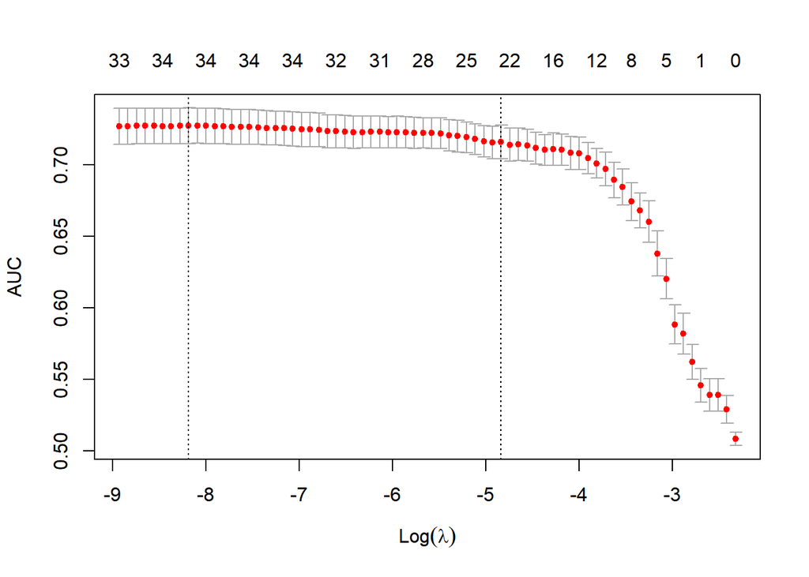

```r
#lassso에 맞는 데이터 생성
trainx = model.matrix(delay~., data=train)
trainy = train$delay
set.seed(123)
#lasso regression 수행, auc기반
cv_lasso = cv.glmnet(x=trainx, y = trainy, alpha=1, family="binomial",type.measure = "auc", nfolds = 10)
#시각화
plot(cv_lasso)
```

```r
#최적의 lambda
lambda  = cv_lasso$lambda[19]
coef(cv_lasso, s = lambda)
```

```
## 36 x 1 sparse Matrix of class "dgCMatrix"
##                       1
## (Intercept) -1.31711364
## (Intercept)  .
## carrierDH    .
## carrierDL   -0.16857770
## carrierMQ    .
## carrierOH    .
## carrierRU    .
## carrierUA    .
## carrierUS   -0.51198457
## deptime7     .
## deptime8    -0.26783649
## deptime9     .
## deptime10   -0.02367341
## deptime11    .
## deptime12   -0.37822906
## deptime13    .
## deptime14   -0.14353661
## deptime15    0.58927474
## deptime16    .
## deptime17    .
## deptime18    .
## deptime19    1.28480740
## deptime20    0.03177835
## deptime21    .
## deptime22    2.54380476
## destJFK      .
## destLGA      .
## originDCA   -0.18351541
## originIAD    .
## weather1     3.07499934
## dayweek2     .
## dayweek3     .
## dayweek4     .
## dayweek5     .
## dayweek6    -0.41604527
## dayweek7     0.15620902
```

```r
#선택한 모델을 활용한 확률
pred_prob = predict(cv_lasso, newx=model.matrix(delay~.,data=test), s= lambda, type="response")
#선택한 모델을 활용한 분류
pred_class = predict(cv_lasso, newx=model.matrix(delay~.,data=test), s= lambda, type="class")
#test 예측 결과 출력
confusionMatrix(factor(pred_class, levels=c("ontime","delayed")),test$delay,positive="delayed")
```

```
## Confusion Matrix and Statistics
##
##           Reference
## Prediction ontime delayed
##    ontime     525     111
##    delayed      0      15
##
##                Accuracy : 0.8295
##                  95% CI : (0.7984, 0.8576)
##     No Information Rate : 0.8065
##     P-Value [Acc > NIR] : 0.07351
##
##                   Kappa : 0.179
##
##  Mcnemar's Test P-Value : < 2e-16
##
##             Sensitivity : 0.11905
##             Specificity : 1.00000
##          Pos Pred Value : 1.00000
##          Neg Pred Value : 0.82547
##              Prevalence : 0.19355
##          Detection Rate : 0.02304
##    Detection Prevalence : 0.02304
##       Balanced Accuracy : 0.55952
##
##        'Positive' Class : delayed
##
```

- 14개의 변수가 포함되었을 때 모델의 AUC값이 bestmodel과 큰 차이가 없으므로 14개 변수 포함된 모델 선택.
- 모델에는 carrier[DL,US], deptime[8,10,12,14,15,19,20,22], originDCA, weather1, dayweek[6,7]이 포함되어있다.
- confusionMatrix결과 testset에 대한 정확도는 0.8295이다.

### 1-9. 6, 7, 8번에서 수립한 logistic regression model들에 대해서, test set에 대한 성능을 나타내는 ROC Curve를 하나의 그래프로 시각화하고, AUC값을 비교해 보자.

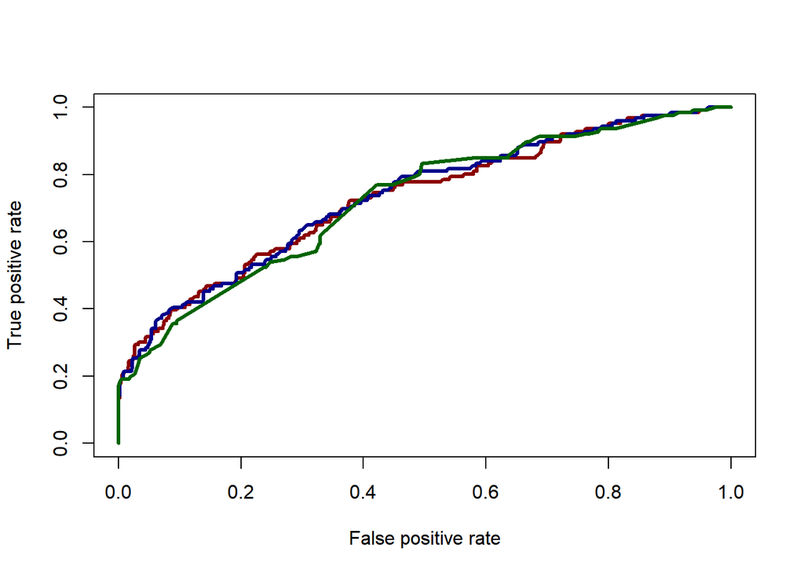

```r
#각 모델의 확률
test_prob = predict(model, test, type="response")
prob_step = predict(model_step, test, type="response")
pred_prob = predict(cv_lasso, newx=model.matrix(delay~.,data=test), s= lambda, type="response")
#각 모델의 test셋 예측결과 및 ROC커브를 위한 계산 결과
pred1 = prediction(test_prob, test$delay, c("ontime","delayed"))
perf1 = performance(pred1, measure="tpr",x.measure = "fpr")
pred2 = prediction(prob_step, test$delay, c("ontime","delayed"))
perf2 = performance(pred2, measure = "tpr", x.measure = "fpr")
pred3 = prediction(pred_prob, test$delay, c("ontime","delayed"))
perf3= performance(pred3, measure = "tpr", x.measure = "fpr")
#ROC 커브 시각화
plot(perf1, col="darkred", lwd=3)
plot(perf2, col="darkblue", lwd=3, add=TRUE)
plot(perf3, col="darkgreen", lwd=3, add=TRUE)
```

```r
#각 모델별 auc 계산
auc1 = performance(pred1, measure = "auc")
auc2 = performance(pred2, measure = "auc")
auc3 = performance(pred3, measure = "auc")
auc1@y.values
```

```
## [[1]]
## [1] 0.729811
```

```r
auc2@y.values
```

```
## [[1]]
## [1] 0.7342101
```

```r
auc3@y.values
```

```
## [[1]]
## [1] 0.7238398
```

| 모델 | AUC |
| --- | --- |
| 6번모델 | 0.729811 |
| 7번모델 | 0.7342101 |
| 8번모델 | 0.7238398 |

- AUC는 7번 모델이 가장 높으나 대체로 비슷하다.

### 1-10. Training set을 대상으로 k-nn을 적용해보자. 이때 train() 함수를 사용한 cross validation으로 Accuracy가 가장 높은 best 값을 찾는다.

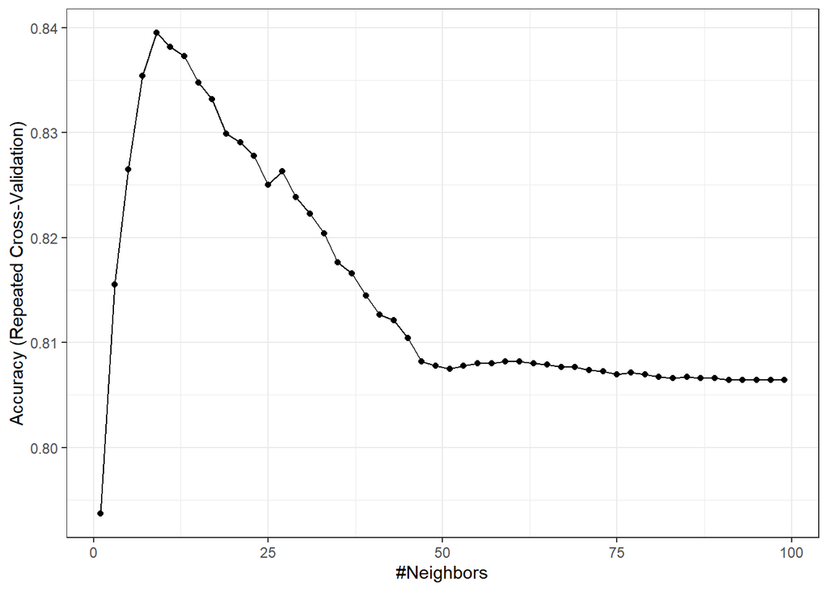

```r
#라벨 분리
train_labels = train[,7]
test_labels=test[,7]
#z_normalized, 5fold,5repeat cv시행
z_normalized = c("center","scale")
cv <- trainControl(method="repeatedcv", number = 5, repeats = 5)
tune_grid <- expand.grid(k = seq(1, 99, 2))
#훈련
knn_fit = train(data=train, delay~., method="knn", trControl = cv,
preProcess = z_normalized, tuneGrid = tune_grid)
#knn 시각화
ggplot(knn_fit)+theme_bw()
```

```r
#best k 값
knn_fit$bestTune
```

```
##   k
## 5 9
```

```r
#test set 예측
test_pred <- predict(knn_fit, test)
confusionMatrix(test_pred, test_labels, positive="delayed")
```

```
## Confusion Matrix and Statistics
##
##           Reference
## Prediction ontime delayed
##    ontime     519      89
##    delayed      6      37
##
##                Accuracy : 0.8541
##                  95% CI : (0.8246, 0.8803)
##     No Information Rate : 0.8065
##     P-Value [Acc > NIR] : 0.0009047
##
##                   Kappa : 0.3765
##
##  Mcnemar's Test P-Value : < 2.2e-16
##
##             Sensitivity : 0.29365
##             Specificity : 0.98857
##          Pos Pred Value : 0.86047
##          Neg Pred Value : 0.85362
##              Prevalence : 0.19355
##          Detection Rate : 0.05684
##    Detection Prevalence : 0.06605
##       Balanced Accuracy : 0.64111
##
##        'Positive' Class : delayed
##
```

- best k는 9 이다.
- knn 모델의 정확도는 0.8541로 앞서 수립한 모델보다 약 2% 정도 더 높은 정확도를 보인다.

## 2. OJ DATASET

```r
#데이터 셋 생성 및 분할
data = OJ
set.seed(123)
split = initial_split(data, prop=0.7, strat="Purchase")
train = training(split)
test = testing(split)
#linear kernel
set.seed(123)
tune.out = tune(svm, Purchase~., data=train, kernel = "linear", ranges=list(cost=10^seq(-3,3)))
summary(tune.out)
```

```
##
## Parameter tuning of 'svm':
##
## - sampling method: 10-fold cross validation
##
## - best parameters:
##  cost
##     1
##
## - best performance: 0.164
##
## - Detailed performance results:
##    cost     error dispersion
## 1 1e-03 0.3266667 0.07678734
## 2 1e-02 0.1720000 0.03997530
## 3 1e-01 0.1693333 0.04171627
## 4 1e+00 0.1640000 0.03502380
## 5 1e+01 0.1666667 0.03281072
## 6 1e+02 0.1680000 0.03278060
## 7 1e+03 0.1653333 0.03781697
```

```r
#베스트 모델
bestmodel = tune.out$best.model
#예측
pred = predict(bestmodel, test)
#메트릭스
confusionMatrix(pred, test$Purchase)
```

```
## Confusion Matrix and Statistics
##
##           Reference
## Prediction  CH  MM
##         CH 171  34
##         MM  24  91
##
##                Accuracy : 0.8188
##                  95% CI : (0.7721, 0.8594)
##     No Information Rate : 0.6094
##     P-Value [Acc > NIR] : 4.773e-16
##
##                   Kappa : 0.6137
##
##  Mcnemar's Test P-Value : 0.2373
##
##             Sensitivity : 0.8769
##             Specificity : 0.7280
##          Pos Pred Value : 0.8341
##          Neg Pred Value : 0.7913
##              Prevalence : 0.6094
##          Detection Rate : 0.5344
##    Detection Prevalence : 0.6406
##       Balanced Accuracy : 0.8025
##
##        'Positive' Class : CH
##
```

```r
#RBF kernel
set.seed(123)
tune.out1 = tune(svm, Purchase~.,data=train, kernel="radial", ranges=list(cost=c(0.01,0.1,1,10,100,1000), gamma=c(0.01,0.1,1,10,100)))
summary(tune.out1)
```

```
##
## Parameter tuning of 'svm':
##
## - sampling method: 10-fold cross validation
##
## - best parameters:
##  cost gamma
##     1  0.01
##
## - best performance: 0.1586667
##
## - Detailed performance results:
##     cost gamma     error dispersion
## 1  1e-02 1e-02 0.3893333 0.05822053
## 2  1e-01 1e-02 0.2280000 0.06983579
```

[output cut: 28 more lines]

```r
#베스트 모델
bestmodel1 = tune.out1$best.model
#예측
pred1 = predict(bestmodel1, test)
#메트릭스
confusionMatrix(pred1, test$Purchase)
```

```
## Confusion Matrix and Statistics
##
##           Reference
## Prediction  CH  MM
##         CH 174  36
##         MM  21  89
##
##                Accuracy : 0.8219
##                  95% CI : (0.7755, 0.8622)
##     No Information Rate : 0.6094
##     P-Value [Acc > NIR] : < 2e-16
##
##                   Kappa : 0.6176
##
##  Mcnemar's Test P-Value : 0.06369
##
##             Sensitivity : 0.8923
##             Specificity : 0.7120
##          Pos Pred Value : 0.8286
##          Neg Pred Value : 0.8091
##              Prevalence : 0.6094
##          Detection Rate : 0.5437
##    Detection Prevalence : 0.6562
##       Balanced Accuracy : 0.8022
##
##        'Positive' Class : CH
##
```

```r
#plynomial kernel
set.seed(123)
tune.out2 = tune(svm, Purchase~.,data=train, kernel="polynomial", ranges=list(cost=c(0.1,1,10,100,1000), degree=c(2,3,4)))
summary(tune.out2)
```

```
##
## Parameter tuning of 'svm':
##
## - sampling method: 10-fold cross validation
##
## - best parameters:
##  cost degree
##    10      2
##
## - best performance: 0.1706667
##
## - Detailed performance results:
##     cost degree     error dispersion
## 1  1e-01      2 0.3093333 0.06993471
## 2  1e+00      2 0.1960000 0.05408726
## 3  1e+01      2 0.1706667 0.05137132
## 4  1e+02      2 0.1733333 0.05106278
## 5  1e+03      2 0.1840000 0.05922962
## 6  1e-01      3 0.2946667 0.07011807
## 7  1e+00      3 0.1946667 0.05767512
## 8  1e+01      3 0.1893333 0.04941135
## 9  1e+02      3 0.1946667 0.04996789
## 10 1e+03      3 0.2040000 0.05222931
## 11 1e-01      4 0.3133333 0.06230154
## 12 1e+00      4 0.2320000 0.05869360
## 13 1e+01      4 0.1826667 0.04075825
## 14 1e+02      4 0.2026667 0.04737036
## 15 1e+03      4 0.2093333 0.04311340
```

```r
#베스트 모델
bestmodel2 = tune.out2$best.model
#예측
pred2 = predict(bestmodel2, test)
#메트릭스
confusionMatrix(pred2, test$Purchase)
```

```
## Confusion Matrix and Statistics
##
##           Reference
## Prediction  CH  MM
##         CH 176  46
##         MM  19  79
##
##                Accuracy : 0.7969
##                  95% CI : (0.7486, 0.8396)
##     No Information Rate : 0.6094
##     P-Value [Acc > NIR] : 5.124e-13
##
##                   Kappa : 0.5561
##
##  Mcnemar's Test P-Value : 0.00126
##
##             Sensitivity : 0.9026
##             Specificity : 0.6320
##          Pos Pred Value : 0.7928
##          Neg Pred Value : 0.8061
##              Prevalence : 0.6094
##          Detection Rate : 0.5500
##    Detection Prevalence : 0.6937
##       Balanced Accuracy : 0.7673
##
##        'Positive' Class : CH
##
```

[output not shown]

- svm모델중 가장 좋은 성능을 보이는 것은 RBF kernel을 사용했을 때이다. 하지만 linear kernel과의 정확도에 크게 차이가 나지 않으므로 적절한 경우에 linear kernel model을 사용하여도 된다고 생각된다.